# esm206-lab7-cje-MLR

Chance English

11/8/2021

```r
knitr::opts_chunk$set(echo = TRUE, message = F, warning = F)


library(tidyverse)
library(here)
library(palmerpenguins)
library(ggplot2)
library(GGally)
library(broom)
library(kableExtra)
library(modelsummary)
library(stargazer)
```

### Intro to GGally : ggpairs() function to create a pairs plot

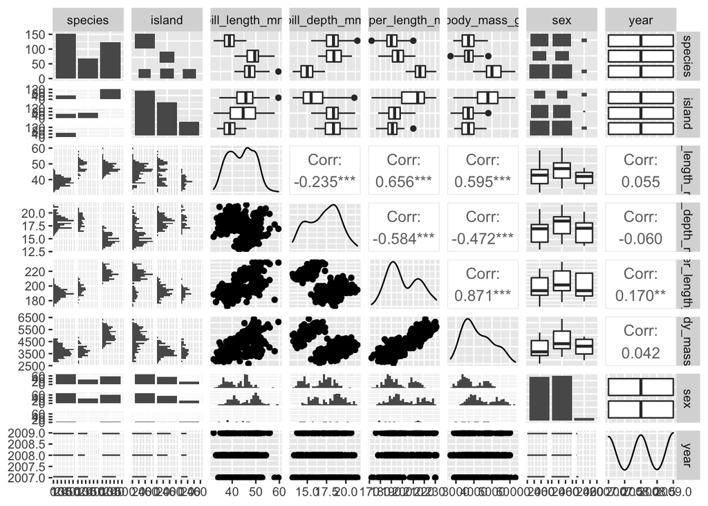

```r
ggpairs(penguins)
```

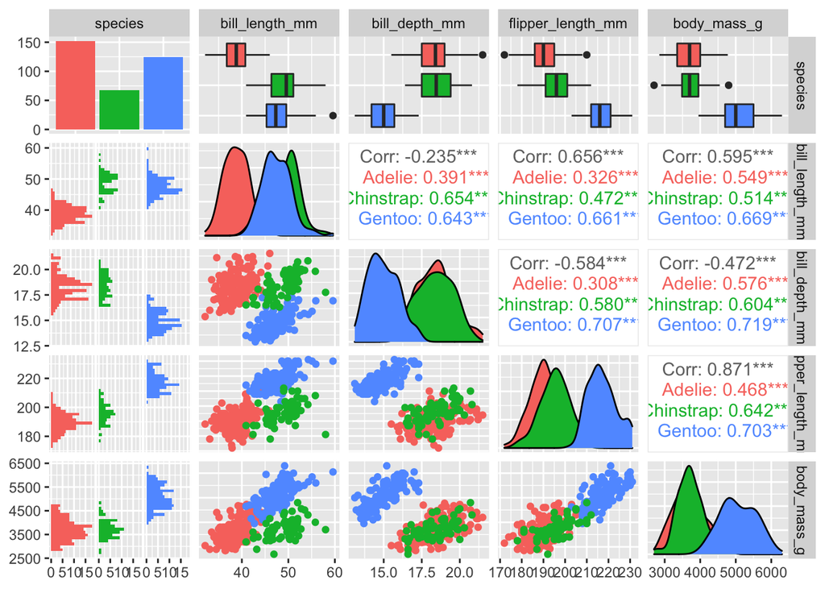

```r
penguins %>%
  select(species, bill_length_mm: body_mass_g) %>%
  ggpairs(aes(color = species))
```

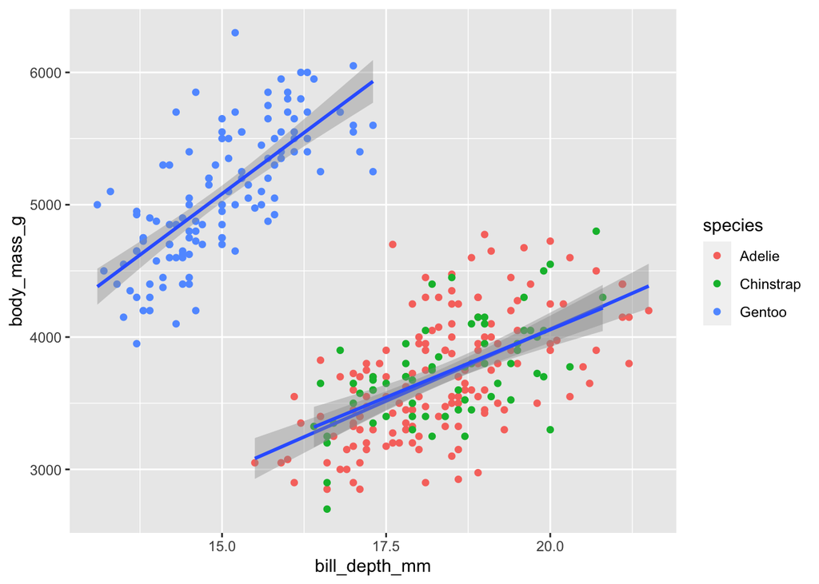

```r
penguins %>% ggplot(aes (x = bill_depth_mm, y = body_mass_g, group = species)) +
  geom_point(aes(color = species)) +
  geom_smooth( method = "lm")
```

```r
# Simpsons Paradox; relationship reverses if we don't account for some variable (in this case not including species as a vairbale results in a negative relationshop between bill depth and body mass)
```

## Multiple Linear Regression - penguins

Use MLR to try to understand the relaitonshio between multiple predictor variables and a single continuous outcome variable (body mass)

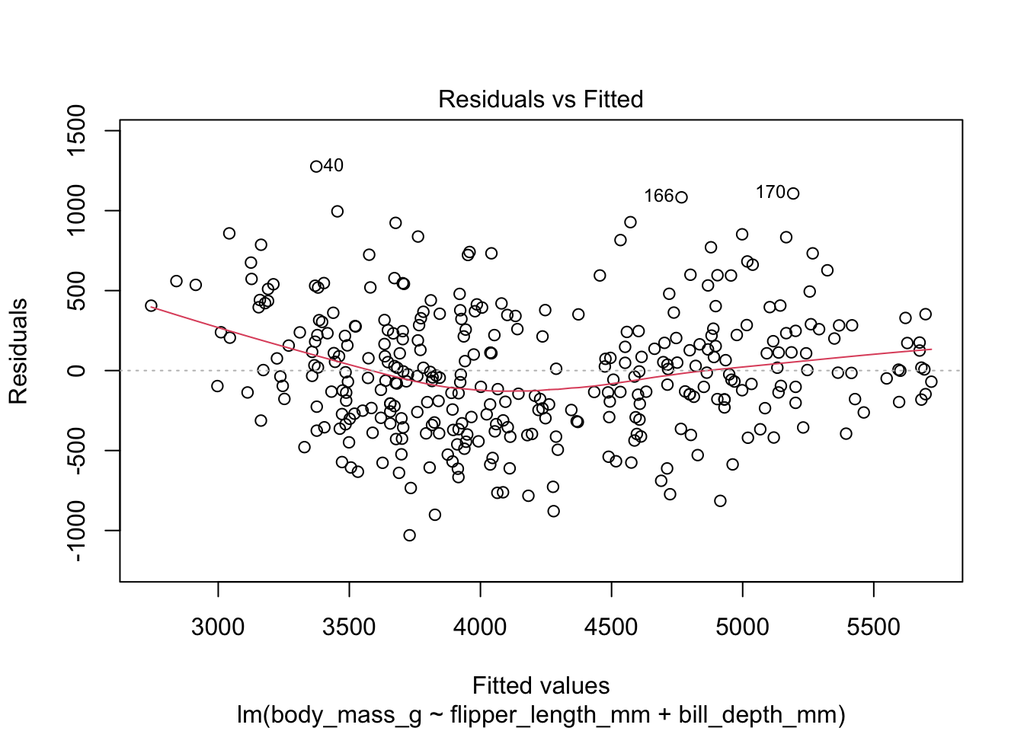

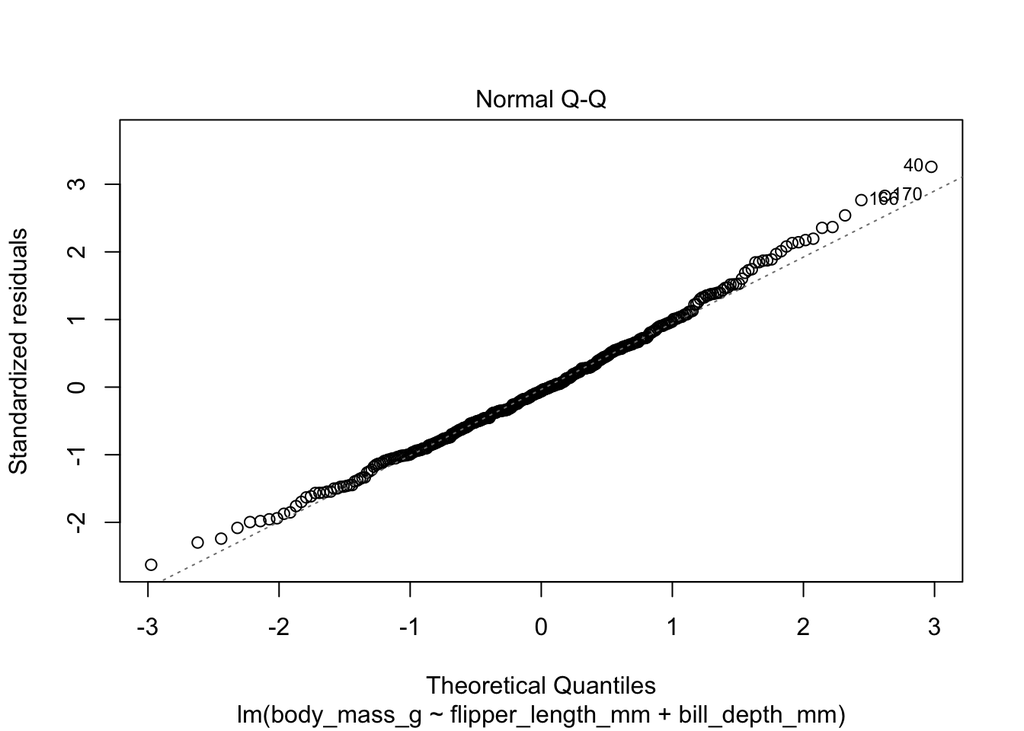

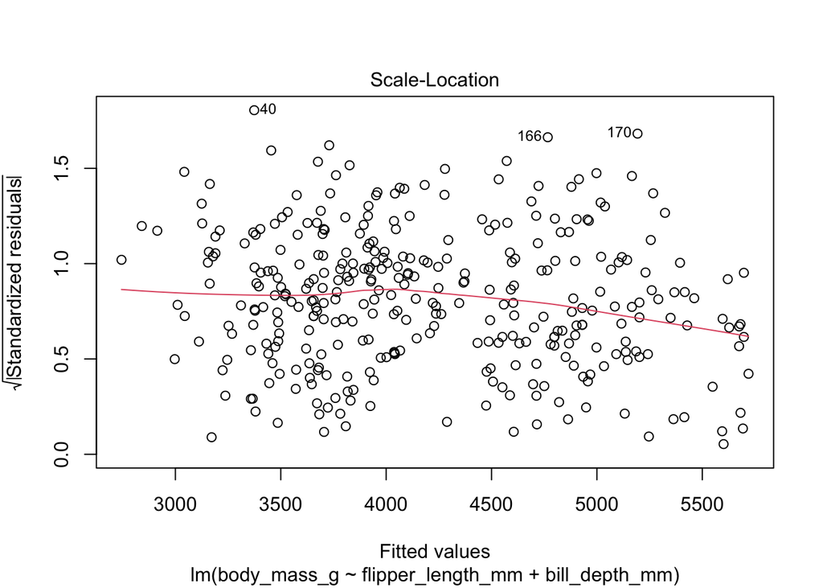

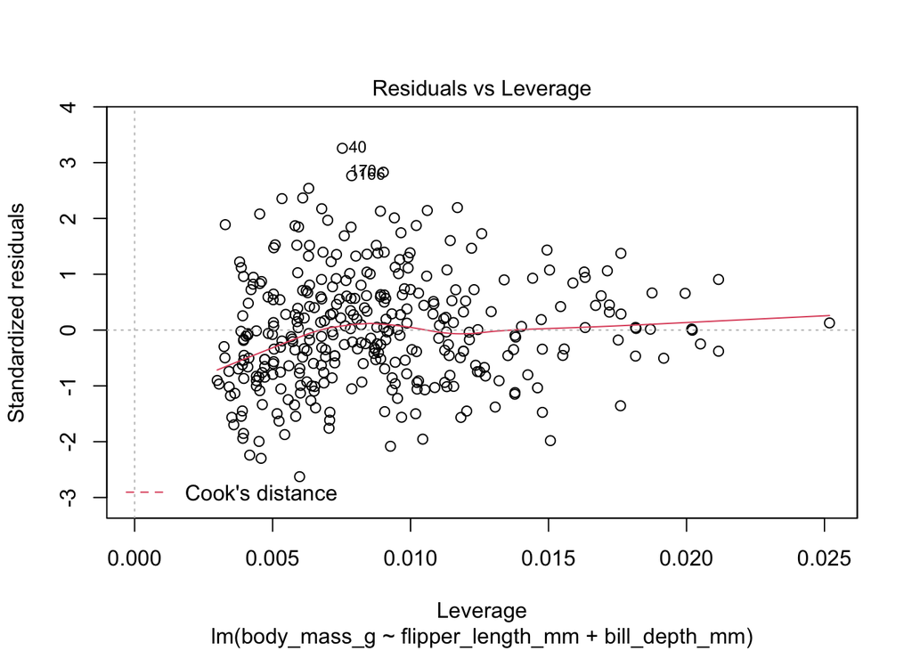

```r
penguin_lm <- lm(body_mass_g ~ flipper_length_mm + bill_depth_mm, data = penguins)


plot(penguin_lm)
```

```r
penguin_lm
```

```
##
## Call:
## lm(formula = body_mass_g ~ flipper_length_mm + bill_depth_mm,
##     data = penguins)
##
## Coefficients:
##       (Intercept)  flipper_length_mm      bill_depth_mm
##          -6541.91              51.54              22.63
```

How would you interpret this coefficient for flipper_length_mm?

We would expect, on average, a 51.54 g increase in penguin body mass for each 1mm increase in flipper length, if evertything else is held constant

### Use summary() function to get more information on the model

```r
summary(penguin_lm)
```

```
##
## Call:
## lm(formula = body_mass_g ~ flipper_length_mm + bill_depth_mm,
##     data = penguins)
##
## Residuals:
##      Min       1Q   Median       3Q      Max
## -1029.78  -271.45   -23.58   245.15  1275.97
##
## Coefficients:
##                    Estimate Std. Error t value Pr(>|t|)
## (Intercept)       -6541.907    540.751 -12.098   <2e-16 ***
## flipper_length_mm    51.541      1.865  27.635   <2e-16 ***
## bill_depth_mm        22.634     13.280   1.704   0.0892 .
## ---
## Signif. codes:  0 '***' 0.001 '**' 0.01 '*' 0.05 '.' 0.1 ' ' 1
##
## Residual standard error: 393.2 on 339 degrees of freedom
##   (2 observations deleted due to missingness)
## Multiple R-squared:  0.761,  Adjusted R-squared:  0.7596
## F-statistic: 539.8 on 2 and 339 DF,  p-value: < 2.2e-16
```

A non-significant coefficient does not mean that you should drop that value from the model

#### Use the ‘broom’ functions tidy and glance

Use broom::tidy to get the coefficient summary in a data frame Use broom:glance to get the model summary ina data frame

```r
penguin_lm_tidy <- tidy(penguin_lm)
penguin_lm_tidy
```

```
## # A tibble: 3 x 5
##   term              estimate std.error statistic  p.value
##   <chr>                <dbl>     <dbl>     <dbl>    <dbl>
## 1 (Intercept)        -6542.     541.      -12.1  2.99e-28
## 2 flipper_length_mm     51.5      1.87     27.6  7.72e-89
## 3 bill_depth_mm         22.6     13.3       1.70 8.92e- 2
```

For each mm increase in bill depth length, on average555 there is a 22.6 g increase in penguin body mass.

## Try another model

We’ve thought alot of about it… the 3 best variables to include in the model are

- flipper length
- species
- sex

Task: create a MLR regression model using those 3 predictor variables

```r
penguins_lm_2 <- lm(body_mass_g ~ flipper_length_mm + species + sex, data = penguins)

penguins_lm_2
```

```
##
## Call:
## lm(formula = body_mass_g ~ flipper_length_mm + species + sex,
##     data = penguins)
##
## Coefficients:
##       (Intercept)  flipper_length_mm   speciesChinstrap      speciesGentoo
##           -365.82              20.02             -87.63             836.26
##           sexmale
##            530.38
```

```r
summary(penguins_lm_2)
```

```
##
## Call:
## lm(formula = body_mass_g ~ flipper_length_mm + species + sex,
##     data = penguins)
##
## Residuals:
##    Min     1Q Median     3Q    Max
## -721.8 -195.7   -5.9  198.6  873.7
##
## Coefficients:
##                   Estimate Std. Error t value Pr(>|t|)
## (Intercept)       -365.817    532.050  -0.688   0.4922
## flipper_length_mm   20.025      2.846   7.037 1.15e-11 ***
## speciesChinstrap   -87.634     46.347  -1.891   0.0595 .
## speciesGentoo      836.260     85.185   9.817  < 2e-16 ***
## sexmale            530.381     37.810  14.027  < 2e-16 ***
## ---
## Signif. codes:  0 '***' 0.001 '**' 0.01 '*' 0.05 '.' 0.1 ' ' 1
##
## Residual standard error: 295.6 on 328 degrees of freedom
##   (11 observations deleted due to missingness)
## Multiple R-squared:  0.8669, Adjusted R-squared:  0.8653
## F-statistic:   534 on 4 and 328 DF,  p-value: < 2.2e-16
```

```r
penguins_lm_2_tidy <- tidy(penguins_lm_2)
penguins_lm_2_tidy
```

```
## # A tibble: 5 x 5
##   term              estimate std.error statistic  p.value
##   <chr>                <dbl>     <dbl>     <dbl>    <dbl>
## 1 (Intercept)         -366.     532.      -0.688 4.92e- 1
## 2 flipper_length_mm     20.0      2.85     7.04  1.15e-11
## 3 speciesChinstrap     -87.6     46.3     -1.89  5.95e- 2
## 4 speciesGentoo        836.      85.2      9.82  4.11e-20
## 5 sexmale              530.      37.8     14.0   2.41e-35
```

Interpreting coefficients with a reference level

If everything else is the same then on average we expect a gento penguin to weigh 836.26 g more than an adelie Chinstrap penguins we expect to be 87.63 g less than an adelie

Predict the mass of a penguin that has a flipper length of 180 mm that is a chinstrap penguin that is female you would plug in a 1 or 0 to evaluate the model

Estimate body mass of an male adelie penguin with flippers thate were 200 mm long

Need to look at the residuals to evaluate the model - normal -homoscadasticity

```r
augment(penguins_lm_2)
```

```
## # A tibble: 333 x 11
##    .rownames body_mass_g flipper_length_… species sex   .fitted .resid    .hat
##    <chr>           <int>            <int> <fct>   <fct>   <dbl>  <dbl>   <dbl>
##  1 1                3750              181 Adelie  male    3789.  -39.1 0.0244
##  2 2                3800              186 Adelie  fema…   3359.  441.  0.00990
##  3 3                3250              195 Adelie  fema…   3539. -289.  0.0163
##  4 5                3450              193 Adelie  fema…   3499.  -49.0 0.0136
##  5 6                3650              190 Adelie  male    3969. -319.  0.0110
##  6 7                3625              181 Adelie  fema…   3259.  366.  0.0128
##  7 8                4675              195 Adelie  male    4069.  606.  0.0101
##  8 13               3200              182 Adelie  fema…   3279.  -78.7 0.0119
##  9 14               3800              191 Adelie  male    3989. -189.  0.0104
## 10 15               4400              198 Adelie  male    4129.  271.  0.0117
## # … with 323 more rows, and 3 more variables: .sigma <dbl>, .cooksd <dbl>,
## #   .std.resid <dbl>
```

```r
# Compare real data to fitted model
```

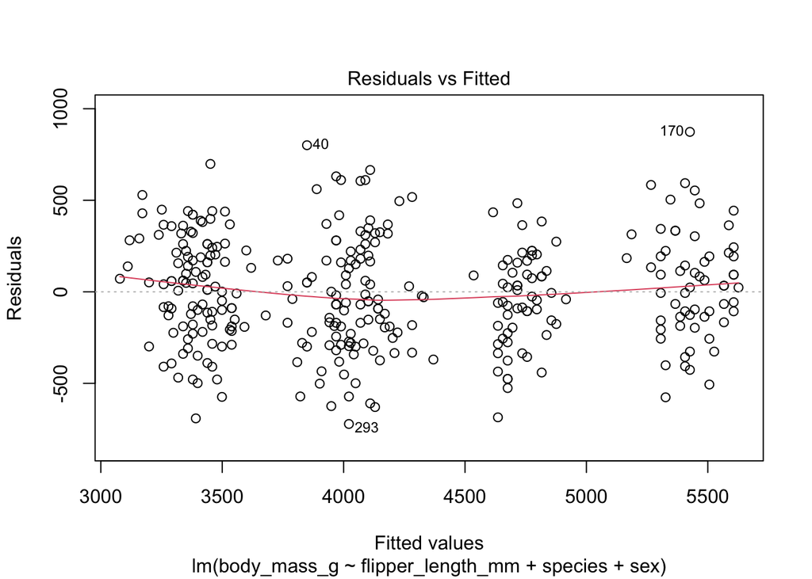

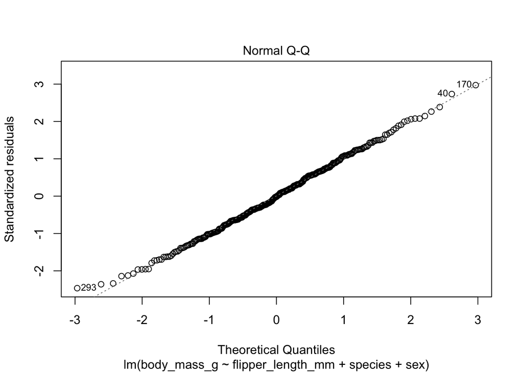

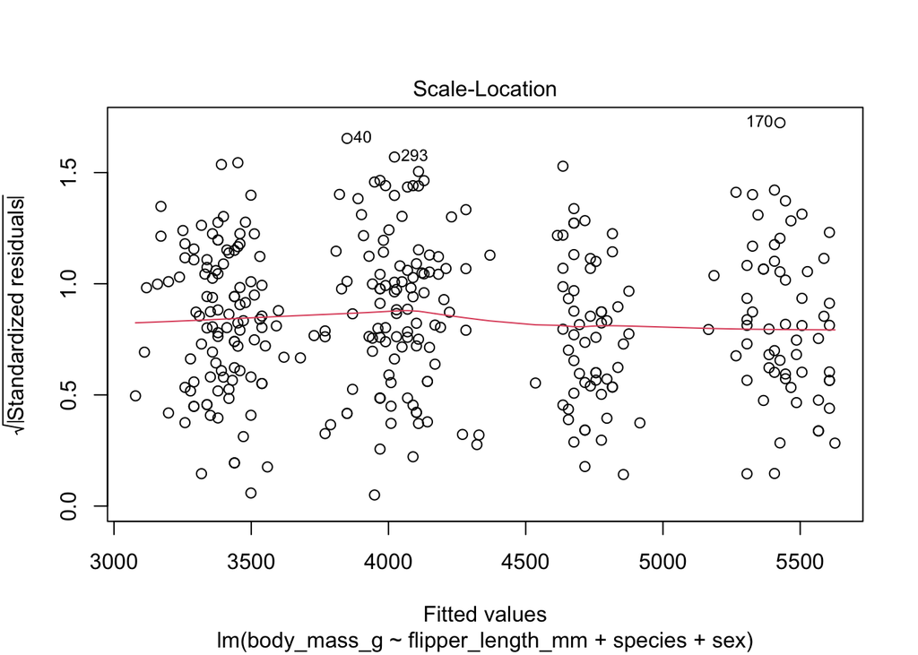

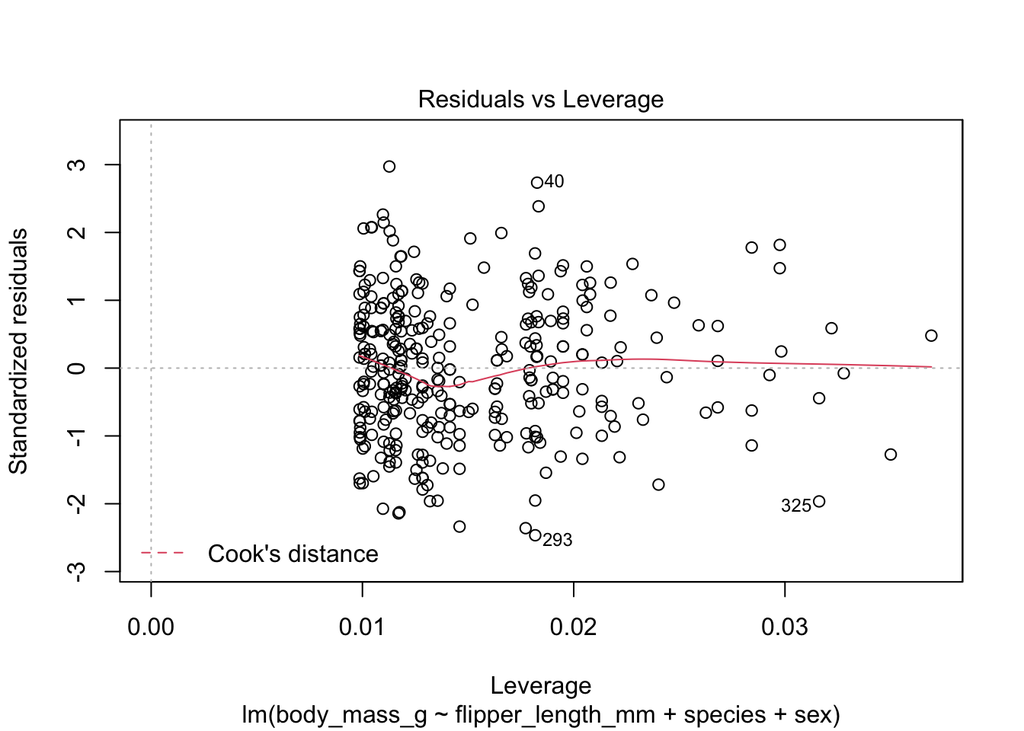

```r
plot(penguins_lm_2)
```

- QQ Plot: residuals are normally distributed (plot 2)
- Plot 1 & 3; vertical distribution of values (residuals) are constistently spread across the model
- Shows any points pulling a disproportional amount of weight
- Conceptual Understanding and expertise that allow me to responsible determine that penguin species, sex and flipper length are reasonable predictor variabless

## Make output tables

Using Model Summary

```r
modelsummary(penguins_lm_2)
```

|  | Model 1 |
| --- | --- |
| (Intercept) | −365.817 |
|  | (532.050) |
| flipper_length_mm | 20.025 |
|  | (2.846) |
| speciesChinstrap | −87.634 |
|  | (46.347) |
| speciesGentoo | 836.260 |
|  | (85.185) |
| sexmale | 530.381 |
|  | (37.810) |
| Num.Obs. | 333 |
| R2 | 0.867 |
| R2 Adj. | 0.865 |
| AIC | 4740.8 |
| BIC | 4763.6 |
| Log.Lik. | −2364.387 |
| F | 534.024 |

Using Stargazer

```r
stargazer(penguins_lm_2, type = "html")
```

[output not shown]